# ces() - Complex Exponential Smoothing

Ivan Svetunkov

2026-09-04

This vignette covers `ces()` and `auto.ces()` functions, which are part of smooth package.

Let’s load the necessary packages:

```r
require(smooth)
```

`ces()` function allows constructing Complex Exponential Smoothing either with no seasonality, or with simple/partial/full one. A simple call for `ces()` results in estimation of non-seasonal model:

```r
ces(BJsales, h=12, holdout=TRUE, silent=FALSE)
```

```
## Time elapsed: 0.02 seconds
## Model estimated using ces() function: CES(none)
## With backcasting initialisation
## Distribution assumed in the model: Normal
## Loss function type: likelihood; Loss function value: 249.4688
##         a0+ia1
## 2.0004+1.0035i
##
## Sample size: 138
## Number of estimated parameters: 5
## Number of degrees of freedom: 133
## Information criteria:
##      AIC     AICc      BIC     BICc
## 508.9376 509.3922 523.5739 524.6937
##
## Forecast errors:
## ME: 0.07; MAE: 1.037; RMSE: 1.276
## sCE: 0.371%; Asymmetry: -12.6%; sMAE: 0.456%; sMSE: 0.003%
## MASE: 0.871; RMSSE: 0.832; rMAE: 0.335; rRMSE: 0.333
```

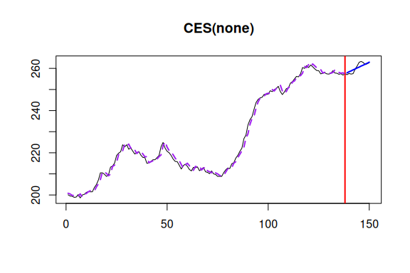

This output is very similar to ones printed out by `adam()` function. The only difference is complex smoothing parameter values which are printed out instead of persistence vector in `adam()`.

If we want automatic model selection, then we use `auto.ces()` function:

```r
auto.ces(AirPassengers, h=12, holdout=TRUE, silent=FALSE)
```

```
## Estimating CES with seasonality: "none" "simple" "partial" "full"
## The best model is with seasonality = "full"
```

```
## Time elapsed: 0.13 seconds
## Model estimated using ces() function: CES(full)
## With backcasting initialisation
## Distribution assumed in the model: Normal
## Loss function type: likelihood; Loss function value: 498.2032
##         a0+ia1
## 1.3681+1.0083i
##         b0+ib1
## 1.8338+1.1154i
##
## Sample size: 132
## Number of estimated parameters: 31
## Number of degrees of freedom: 101
## Information criteria:
##      AIC     AICc      BIC     BICc
## 1058.407 1078.246 1147.773 1196.211
##
## Forecast errors:
## ME: -3.162; MAE: 9.592; RMSE: 13.61
## sCE: -14.457%; Asymmetry: -18.3%; sMAE: 3.654%; sMSE: 0.269%
## MASE: 0.398; RMSSE: 0.434; rMAE: 0.126; rRMSE: 0.132
```

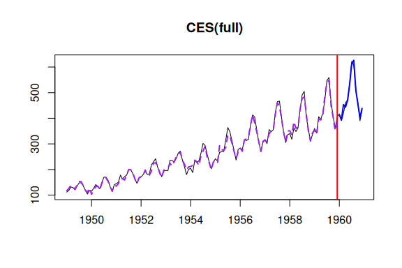

```r
ces(BJsales, h=12, holdout=TRUE, initial="back")
```

```
## Time elapsed: 0.03 seconds
## Model estimated using ces() function: CES(none)
## With backcasting initialisation
## Distribution assumed in the model: Normal
## Loss function type: likelihood; Loss function value: 249.4688
##         a0+ia1
## 2.0004+1.0035i
##
## Sample size: 138
## Number of estimated parameters: 5
## Number of degrees of freedom: 133
## Information criteria:
##      AIC     AICc      BIC     BICc
## 508.9376 509.3922 523.5739 524.6937
##
## Forecast errors:
## ME: 0.07; MAE: 1.037; RMSE: 1.276
## sCE: 0.371%; Asymmetry: -12.6%; sMAE: 0.456%; sMSE: 0.003%
## MASE: 0.871; RMSSE: 0.832; rMAE: 0.335; rRMSE: 0.333
```

The function also works with explanatory variables if the data frame or a matrix is provided instead of the vector of values:

```r
BJData <- cbind(y=BJsales, x=BJsales.lead)
cesModel <- ces(BJData, h=12, holdout=TRUE, regressors="use")
```

Finally, all the main methods for the adam function are supported by `ces()` as well. For example, here how we can produce prediction interval:

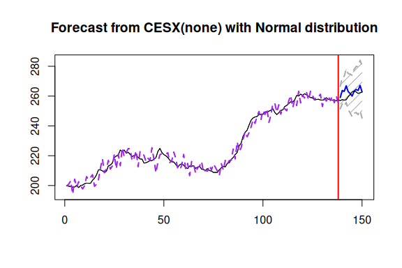

```r
forecast(cesModel, h=12, interval="pred") |> plot()
```